# Summarizing Data Activity

CO2 Uptake Experiment

# Background

This example is taken from an experiment listed in the R help files under `?CO2`.

“An experiment on the cold tolerance of the grass species Echinochloa crus-galli was conducted. The CO2 uptake of six plants from Quebec and six plants from Mississippi was measured at several levels of ambient CO2 concentration. Half the plants of each type were chilled overnight before the experiment was conducted.” Plants were considered tolerant to the cold if they were still able to achieve high CO2 uptake values after being chilled.

Ignoring the Plant ID for a moment, there are three factors that possibly effect the `uptake` of a plant. These include `Type`, `Treatment`, and `conc`. The factor `Type` has two levels, **Quebec** and **Mississippi**. The factor `Treatment` has two levels **chilled** and **nonchilled** and the factor `conc` has seven levels 95, 175, 250, 350, 500, 675, and 1000.

Conc is related to the ambient concentration of CO2.

# Summarizing Data

Our main interest is CO2 uptake and how the other factors impact it. We will first do a univariate analysis of uptake.

## Univariate Analysis

Create a table with the overall summary statistics for uptake:

```r
# This is NEW!  if you tell R to knit the favstats output using the "kable" function, it will look a lot nicer when the document is rendered.

knitr::kable(favstats(CO2$uptake))
```

|  | min | Q1 | median | Q3 | max | mean | sd | n | missing |
| --- | --- | --- | --- | --- | --- | --- | --- | --- | --- |
|  | 7.7 | 17.9 | 28.3 | 37.125 | 45.5 | 27.2131 | 10.81441 | 84 | 0 |

Create a histogram of the CO2 uptake across all groups:

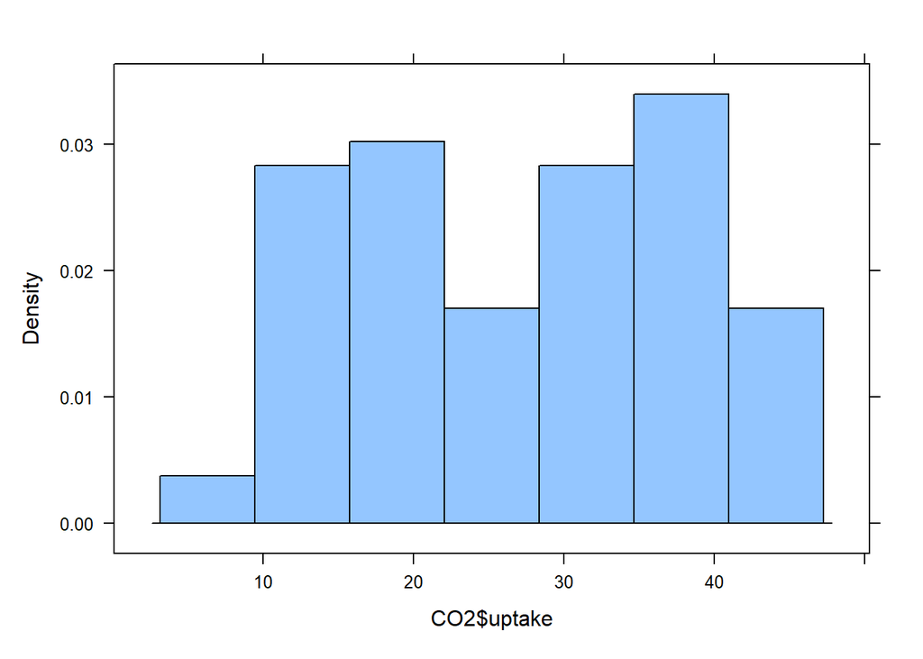

```r
histogram(CO2$uptake)
```

# What Factors Impact Uptake?

We will now look at how other factors might impact CO2 uptake.

## Impact of Plant Type on Uptake

Create a table of summary statistics of uptake for each `Type` of plants used in the experiment.

```r
knitr::kable(favstats(CO2$uptake ~ CO2$Type))
```

| CO2$Type | min | Q1 | median | Q3 | max | mean | sd | n | missing |
| --- | --- | --- | --- | --- | --- | --- | --- | --- | --- |
| Quebec | 9.3 | 30.325 | 37.15 | 40.15 | 45.5 | 33.54286 | 9.673830 | 42 | 0 |
| Mississippi | 7.7 | 13.875 | 19.30 | 28.05 | 35.5 | 20.88333 | 7.815773 | 42 | 0 |

Create a side-by-side boxplot of uptake for each `Type` of plants used in the experiment.

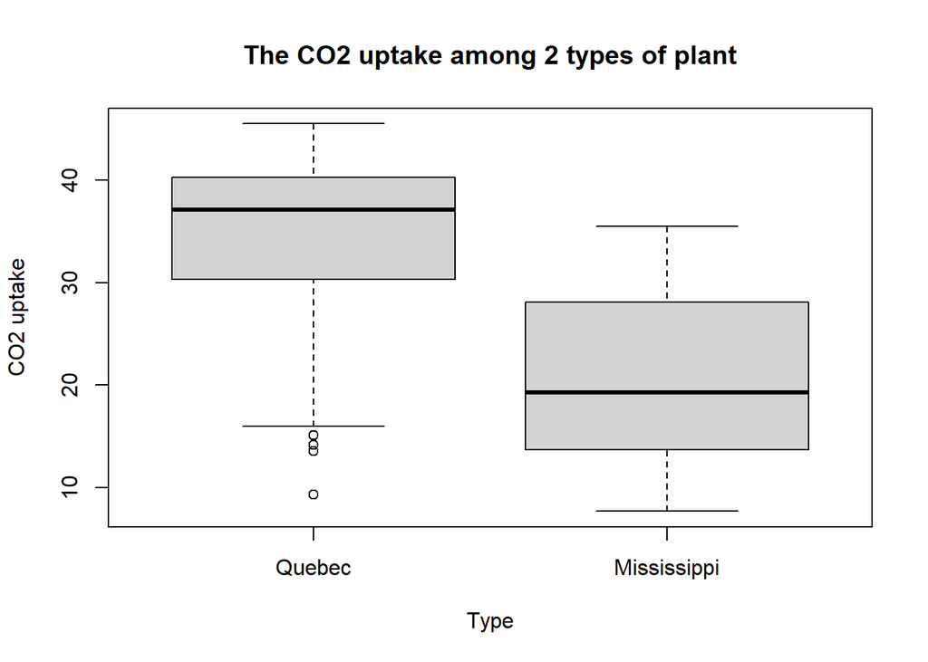

```r
boxplot(CO2$uptake ~ CO2$Type, main="The CO2 uptake among 2 types of plant", xlab="Type", ylab="CO2 uptake")
```

## Impact of Treatment on Uptake

Create a table of summary statistics of uptake for each `Treatment` used in the experiment.

```r
knitr::kable(favstats(CO2$uptake ~ CO2$Treatment))
```

| CO2$Treatment | min | Q1 | median | Q3 | max | mean | sd | n | missing |
| --- | --- | --- | --- | --- | --- | --- | --- | --- | --- |
| nonchilled | 10.6 | 26.475 | 31.3 | 38.7 | 45.5 | 30.64286 | 9.704994 | 42 | 0 |
| chilled | 7.7 | 14.525 | 19.7 | 34.9 | 42.4 | 23.78333 | 10.884312 | 42 | 0 |

Create a side-by-side boxplot of uptake for each `Treatment` used in the experiment.

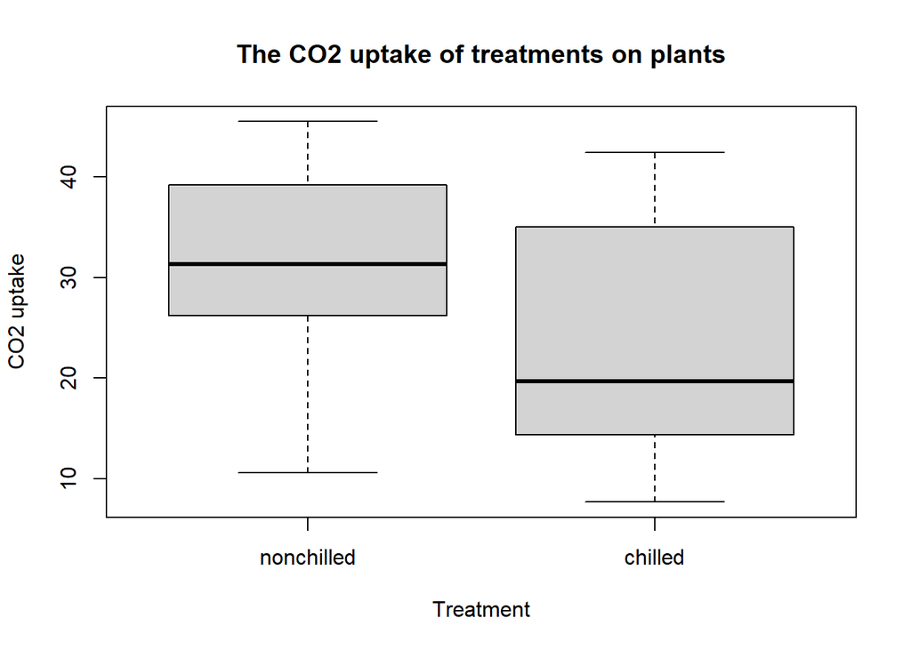

```r
boxplot(CO2$uptake ~ CO2$Treatment, main="The CO2 uptake of treatments on plants", xlab="Treatment", ylab="CO2 uptake")
```

## Impact of Ambient CO2 Concentration on Uptake

Create a table of summary statistics of uptake for each level of ambient CO2, `conc`, found in the experiment.

```r
knitr::kable(favstats(CO2$uptake ~ CO2$conc))
```

| CO2$conc | min | Q1 | median | Q3 | max | mean | sd | n | missing |
| --- | --- | --- | --- | --- | --- | --- | --- | --- | --- |
| 95 | 7.7 | 10.575 | 11.65 | 14.425 | 16.2 | 12.25833 | 2.735111 | 12 | 0 |
| 175 | 11.4 | 18.900 | 21.50 | 27.300 | 32.4 | 22.28333 | 6.271992 | 12 | 0 |
| 250 | 12.3 | 23.875 | 30.45 | 35.525 | 40.3 | 28.87500 | 8.988895 | 12 | 0 |
| 350 | 13.0 | 25.650 | 32.90 | 37.600 | 42.1 | 30.66667 | 9.596527 | 12 | 0 |
| 500 | 12.5 | 26.250 | 32.45 | 38.675 | 42.9 | 30.87500 | 9.671056 | 12 | 0 |
| 675 | 13.7 | 26.625 | 33.90 | 39.300 | 43.9 | 31.95000 | 9.534960 | 12 | 0 |
| 1000 | 14.4 | 26.325 | 37.10 | 41.650 | 45.5 | 33.58333 | 10.411867 | 12 | 0 |

Create a side-by-side boxplot of uptake for each level of ambient CO2, `conc`, found used in the experiment.

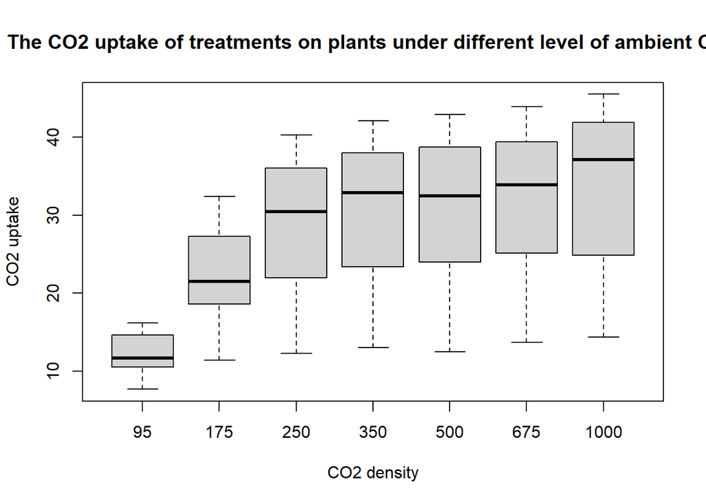

```r
boxplot(CO2$uptake ~ CO2$conc, main="The CO2 uptake of treatments on plants under different level of ambient CO2", xlab="CO2 density", ylab="CO2 uptake")
```

# Conclusion

## What makes this an experiment?

The background suggests this study was an experiment. In your own words, describe the difference between an experiment and an observational study.

What might this study have looked like if it had been an observational study?

A: It’s an experiment since there are multiple different factors in the experiment, such as the level of ambient CO2, different treatments(chilled and non-chilled), and comparing with different plants.

## What is the Population of this study?

Describe in your own words what the population of this study could be. How broad can we make our conclusions?

A: The population should be the grass species Echinochloa crus-galli from Quebec and Mississippi. We can have the following conclusions: 1. In general, the plants from Quebec have higher CO2 uptake capability than the ones from Mississippi 2. The nonchilled plant has a better uptake performance than the chilled one. 3. As the level of ambient CO2 increase, the CO2 uptake of both species increase.

## What are your recommendations?

If you were to recommend a planting scenario to maximize CO2 uptake, what would you recommend based on the summaries provided?

A: Use the plants from Quebec, avoid chilled possibility, and put them in the higher CO2 level area.